# A3.1 PCA y Sistemas de Recomendación

**Materia:** Inteligencia Artificial

**Alumno:** Emiliano Pascual Pinales Sanchez

**Matrícula:** 657657

## Introducción

En esta actividad se utilizarán diferentes conjuntos de datos para aplicar PCA, comparar modelos de clasificación y desarrollar un sistema de recomendación de películas. Se explicará cada procedimiento y se analizarán los resultados obtenidos.

```python
import pandas as pd
import numpy as np
import matplotlib.pyplot as plt
import seaborn as sns

from sklearn.datasets import load_breast_cancer

datos = load_breast_cancer(as_frame=True)

X = datos.data
y = datos.target

print("Cantidad de registros:", X.shape[0])
print("Cantidad de variables:", X.shape[1])
print("Clases:", datos.target_names)
print("Valores faltantes:", X.isna().sum().sum())

display(X.head())
```

```
Cantidad de registros: 569
Cantidad de variables: 30
Clases: ['malignant' 'benign']
Valores faltantes: 0
```

|  | mean radius | mean texture | mean perimeter | mean area | mean smoothness | mean compactness | mean concavity | mean concave points | mean symmetry | mean fractal dimension | ... | worst radius | worst texture | worst perimeter | worst area | worst smoothness | worst compactness | worst concavity | worst concave points | worst symmetry | worst fractal dimension |
| --- | --- | --- | --- | --- | --- | --- | --- | --- | --- | --- | --- | --- | --- | --- | --- | --- | --- | --- | --- | --- | --- |
| 0 | 17.99 | 10.38 | 122.80 | 1001.0 | 0.11840 | 0.27760 | 0.3001 | 0.14710 | 0.2419 | 0.07871 | ... | 25.38 | 17.33 | 184.60 | 2019.0 | 0.1622 | 0.6656 | 0.7119 | 0.2654 | 0.4601 | 0.11890 |
| 1 | 20.57 | 17.77 | 132.90 | 1326.0 | 0.08474 | 0.07864 | 0.0869 | 0.07017 | 0.1812 | 0.05667 | ... | 24.99 | 23.41 | 158.80 | 1956.0 | 0.1238 | 0.1866 | 0.2416 | 0.1860 | 0.2750 | 0.08902 |
| 2 | 19.69 | 21.25 | 130.00 | 1203.0 | 0.10960 | 0.15990 | 0.1974 | 0.12790 | 0.2069 | 0.05999 | ... | 23.57 | 25.53 | 152.50 | 1709.0 | 0.1444 | 0.4245 | 0.4504 | 0.2430 | 0.3613 | 0.08758 |
| 3 | 11.42 | 20.38 | 77.58 | 386.1 | 0.14250 | 0.28390 | 0.2414 | 0.10520 | 0.2597 | 0.09744 | ... | 14.91 | 26.50 | 98.87 | 567.7 | 0.2098 | 0.8663 | 0.6869 | 0.2575 | 0.6638 | 0.17300 |
| 4 | 20.29 | 14.34 | 135.10 | 1297.0 | 0.10030 | 0.13280 | 0.1980 | 0.10430 | 0.1809 | 0.05883 | ... | 22.54 | 16.67 | 152.20 | 1575.0 | 0.1374 | 0.2050 | 0.4000 | 0.1625 | 0.2364 | 0.07678 |

5 rows × 30 columns

## 1. Exploración de los datos

El conjunto de datos contiene 569 registros y 30 variables relacionadas con características de tumores. Los registros se dividen en dos clases: malignos y benignos. No se encontraron valores faltantes.

Se realizarán gráficas de densidad y dispersión para observar cómo se distribuyen los datos y si las características permiten distinguir entre ambas clases.

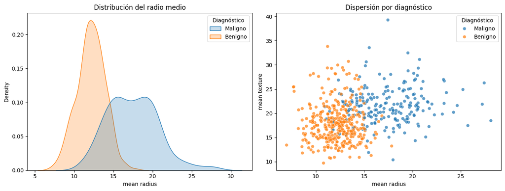

```
Cantidad de registros por clase:
Diagnóstico
Benigno    357
Maligno    212
Name: count, dtype: int64
```

```python
df_graficas = datos.data[["mean radius", "mean texture"]].copy()
df_graficas["Diagnóstico"] = datos.target.map({
    0: "Maligno",
    1: "Benigno"
})

fig, axes = plt.subplots(1, 2, figsize=(13, 5))

sns.kdeplot(
    data=df_graficas,
    x="mean radius",
    hue="Diagnóstico",
    fill=True,
    common_norm=False,
    ax=axes[0]
)
axes[0].set_title("Distribución del radio medio")

sns.scatterplot(
    data=df_graficas,
    x="mean radius",
    y="mean texture",
    hue="Diagnóstico",
    alpha=0.7,
    ax=axes[1]
)
axes[1].set_title("Dispersión por diagnóstico")

plt.tight_layout()
plt.show()

print("Cantidad de registros por clase:")
print(df_graficas["Diagnóstico"].value_counts())
```

### Interpretación de las gráficas

En la gráfica de densidad se observa que los tumores malignos generalmente presentan un radio medio mayor que los benignos. En la gráfica de dispersión también se aprecia cierta separación entre ambas clases, aunque algunos puntos se encuentran mezclados. Esto indica que estas características pueden ayudar a clasificar los tumores, pero no son suficientes para distinguir todos los casos correctamente.

## 2. Clasificación mediante regresión logística

Los datos se dividirán en 70% para entrenamiento y 30% para prueba. Se utilizará la estandarización para evitar que las diferencias de escala afecten al modelo.

Después se entrenará una regresión logística y se buscará mejorar el F1-score mediante diferentes valores de regularización. Finalmente, se evaluará el desempeño utilizando Accuracy, F1-score y AUC.

```python
from sklearn.model_selection import train_test_split, GridSearchCV
from sklearn.preprocessing import StandardScaler
from sklearn.linear_model import LogisticRegression
from sklearn.pipeline import make_pipeline
from sklearn.metrics import accuracy_score, f1_score, roc_auc_score

# La clase 1 representa tumores malignos
y_maligno = (y == 0).astype(int)

# División 70% entrenamiento y 30% prueba
X_train, X_test, y_train, y_test = train_test_split(
    X, y_maligno,
    test_size=0.30,
    random_state=42,
    stratify=y_maligno
)

# Estandarización y regresión logística
modelo = make_pipeline(
    StandardScaler(),
    LogisticRegression(max_iter=5000, random_state=42)
)

# Búsqueda del mejor F1-score
parametros = {
    "logisticregression__C": [0.01, 0.1, 1, 10, 100]
}

busqueda = GridSearchCV(
    modelo,
    parametros,
    cv=5,
    scoring="f1",
    n_jobs=-1
)

busqueda.fit(X_train, y_train)

# Evaluación en datos de prueba
mejor_modelo = busqueda.best_estimator_
predicciones = mejor_modelo.predict(X_test)
probabilidades = mejor_modelo.predict_proba(X_test)[:, 1]

print("Entrenamiento:", X_train.shape[0])
print("Prueba:", X_test.shape[0])
print("Mejor C:", busqueda.best_params_)
print("Accuracy:", round(accuracy_score(y_test, predicciones), 4))
print("F1-score:", round(f1_score(y_test, predicciones), 4))
print("AUC:", round(roc_auc_score(y_test, probabilidades), 4))
```

```
Entrenamiento: 398
Prueba: 171
Mejor C: {'logisticregression__C': 1}
Accuracy: 0.9708
F1-score: 0.96
AUC: 0.9975
```

### Interpretación de los resultados

El modelo obtuvo un Accuracy de 97.08%, un F1-score de 0.96 y un AUC de 0.9975. Estos resultados muestran que la regresión logística logra distinguir correctamente la mayoría de los casos y tiene una buena capacidad para diferenciar entre tumores benignos y malignos.

Este modelo servirá como referencia para comparar si al aplicar PCA podemos reducir la cantidad de variables sin perder demasiado desempeño.

## 3. Análisis de Componentes Principales (PCA)

PCA permite reducir la cantidad de variables de un conjunto de datos conservando la mayor parte de su variabilidad.

En esta sección se aplicará PCA a los datos de entrenamiento previamente estandarizados. Se analizará la varianza explicada por cada componente y la varianza acumulada para determinar cuántos componentes es conveniente conservar.

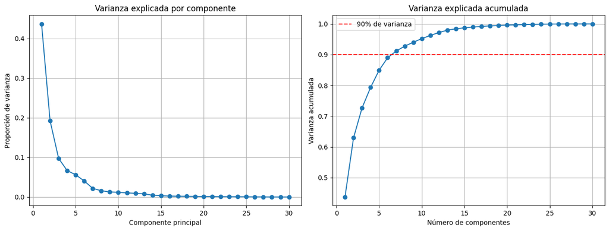

```
60% de varianza: 2 componentes
70% de varianza: 3 componentes
80% de varianza: 5 componentes
90% de varianza: 7 componentes
95% de varianza: 10 componentes
```

```python
from sklearn.decomposition import PCA

# Estandarizar usando solo los datos de entrenamiento
scaler_pca = StandardScaler()
X_train_scaled = scaler_pca.fit_transform(X_train)
X_test_scaled = scaler_pca.transform(X_test)

# Aplicar PCA
pca_completo = PCA()
pca_completo.fit(X_train_scaled)

# Varianza explicada y acumulada
varianza = pca_completo.explained_variance_ratio_
varianza_acumulada = np.cumsum(varianza)

# Graficar resultados
fig, axes = plt.subplots(1, 2, figsize=(13, 5))

axes[0].plot(
    range(1, len(varianza) + 1),
    varianza, marker="o"
)
axes[0].set_title("Varianza explicada por componente")
axes[0].set_xlabel("Componente principal")
axes[0].set_ylabel("Proporción de varianza")
axes[0].grid(True)

axes[1].plot(
    range(1, len(varianza_acumulada) + 1),
    varianza_acumulada, marker="o"
)
axes[1].axhline(
    y=0.90, color="red", linestyle="--",
    label="90% de varianza"
)
axes[1].set_title("Varianza explicada acumulada")
axes[1].set_xlabel("Número de componentes")
axes[1].set_ylabel("Varianza acumulada")
axes[1].legend()
axes[1].grid(True)

plt.tight_layout()
plt.show()

# Componentes necesarios para distintos porcentajes
for porcentaje in [0.60, 0.70, 0.80, 0.90, 0.95]:
    n = np.searchsorted(varianza_acumulada, porcentaje) + 1
    print(f"{porcentaje:.0%} de varianza: {n} componentes")
```

### Interpretación de la varianza explicada

Los primeros componentes principales concentran la mayor parte de la variabilidad de los datos. Se observa que con 7 componentes se conserva al menos el 90% de la varianza, mientras que con 10 se alcanza el 95%.

Esto demuestra que PCA permite reducir considerablemente la cantidad de variables sin perder gran parte de la información. Sin embargo, todavía es necesario comprobar si esta reducción afecta los resultados de clasificación.

## 4. Comparación de correlaciones y visualización

Se compararán las correlaciones de los datos originales estandarizados con las de los componentes principales. Esto permitirá observar cómo PCA transforma las variables originales en componentes que no están correlacionados entre sí.

También se utilizarán los primeros dos componentes para visualizar la distribución de las clases.

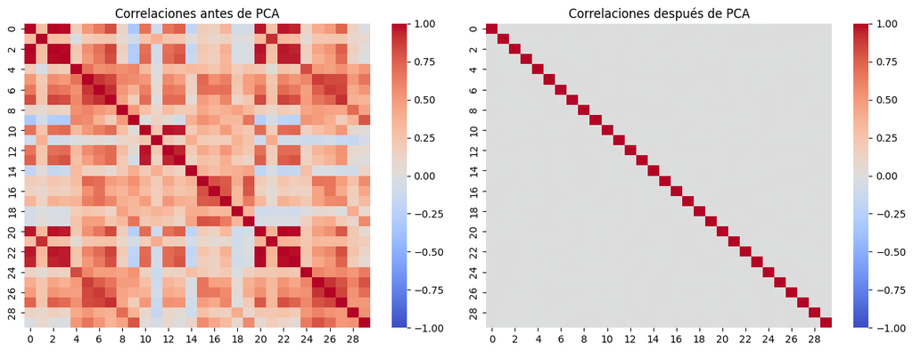

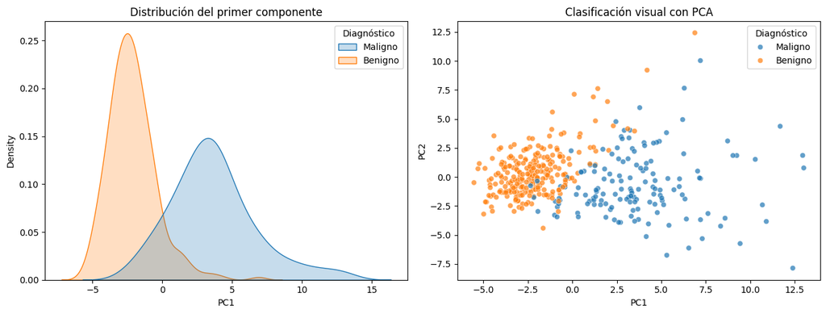

```python
# Transformar datos con PCA
X_train_pca = pca_completo.transform(X_train_scaled)

# Comparar correlaciones
fig, axes = plt.subplots(1, 2, figsize=(13, 5))

sns.heatmap(
    np.corrcoef(X_train_scaled, rowvar=False),
    cmap="coolwarm", vmin=-1, vmax=1,
    ax=axes[0]
)
axes[0].set_title("Correlaciones antes de PCA")

sns.heatmap(
    np.corrcoef(X_train_pca, rowvar=False),
    cmap="coolwarm", vmin=-1, vmax=1,
    ax=axes[1]
)
axes[1].set_title("Correlaciones después de PCA")

plt.tight_layout()
plt.show()

# Visualizar los primeros dos componentes
df_pca = pd.DataFrame(
    X_train_pca[:, :2],
    columns=["PC1", "PC2"]
)

df_pca["Diagnóstico"] = np.where(
    np.asarray(y_train) == 1,
    "Maligno",
    "Benigno"
)

fig, axes = plt.subplots(1, 2, figsize=(13, 5))

sns.kdeplot(
    data=df_pca,
    x="PC1",
    hue="Diagnóstico",
    fill=True,
    common_norm=False,
    ax=axes[0]
)
axes[0].set_title("Distribución del primer componente")

sns.scatterplot(
    data=df_pca,
    x="PC1",
    y="PC2",
    hue="Diagnóstico",
    alpha=0.7,
    ax=axes[1]
)
axes[1].set_title("Clasificación visual con PCA")

plt.tight_layout()
plt.show()
```

### Interpretación de las correlaciones y visualizaciones

Antes de aplicar PCA se observan varias variables relacionadas entre sí. Después de la transformación, las correlaciones entre los componentes principales son prácticamente cero.

En las gráficas de distribución se aprecia que PCA permite distinguir parcialmente los tumores benignos y malignos, aunque todavía existen algunos casos mezclados. Esto muestra que los componentes principales conservan información útil para la clasificación.

## 5. Comparación de modelos con PCA

Se entrenarán modelos de regresión logística utilizando distintas cantidades de componentes principales. Se compararán sus resultados con el modelo original de 30 variables mediante Accuracy, F1-score y AUC.

El objetivo es identificar si es posible reducir la cantidad de variables manteniendo un buen desempeño de clasificación.

```
Comparación de modelos:
```

|  | Componentes | Accuracy | F1-score | AUC |
| --- | --- | --- | --- | --- |
| 0 | 30 (original) | 0.9708 | 0.9600 | 0.9975 |
| 1 | 2 | 0.9415 | 0.9167 | 0.9974 |
| 2 | 3 | 0.9591 | 0.9431 | 0.9977 |
| 3 | 5 | 0.9883 | 0.9841 | 0.9981 |
| 4 | 7 | 0.9825 | 0.9764 | 0.9982 |
| 5 | 10 | 0.9708 | 0.9600 | 0.9982 |

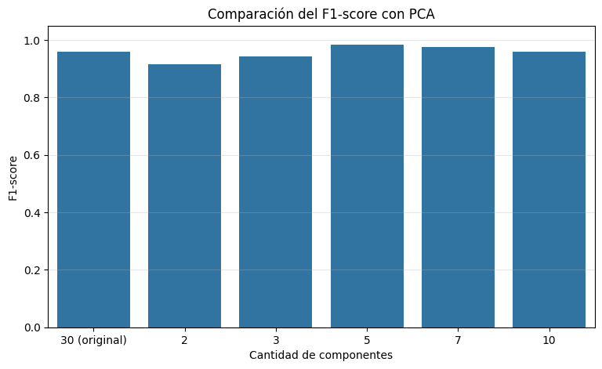

```python
from sklearn.pipeline import make_pipeline

# Resultados del modelo original
resultados = [{
    "Componentes": "30 (original)",
    "Accuracy": accuracy_score(y_test, predicciones),
    "F1-score": f1_score(y_test, predicciones),
    "AUC": roc_auc_score(y_test, probabilidades)
}]

# Modelos con diferentes cantidades de componentes
for n in [2, 3, 5, 7, 10]:
    modelo_pca = make_pipeline(
        StandardScaler(),
        PCA(n_components=n),
        LogisticRegression(
            C=1,
            max_iter=5000,
            random_state=42
        )
    )

    modelo_pca.fit(X_train, y_train)

    pred = modelo_pca.predict(X_test)
    prob = modelo_pca.predict_proba(X_test)[:, 1]

    resultados.append({
        "Componentes": str(n),
        "Accuracy": accuracy_score(y_test, pred),
        "F1-score": f1_score(y_test, pred),
        "AUC": roc_auc_score(y_test, prob)
    })

tabla_resultados = pd.DataFrame(resultados)

print("Comparación de modelos:")
display(tabla_resultados.round(4))

# Comparación visual del F1-score
plt.figure(figsize=(9, 5))

sns.barplot(
    data=tabla_resultados,
    x="Componentes",
    y="F1-score"
)

plt.title("Comparación del F1-score con PCA")
plt.xlabel("Cantidad de componentes")
plt.ylabel("F1-score")
plt.ylim(0, 1.05)
plt.grid(axis="y", alpha=0.3)
plt.show()
```

### Interpretación de la comparación

Los resultados muestran que PCA permite reducir la cantidad de variables manteniendo un buen desempeño. El modelo con 5 componentes obtuvo el mejor F1-score de 0.9841, superando al modelo original de 30 variables, que obtuvo 0.96.

Por otro lado, el modelo con 7 componentes conserva al menos el 90% de la varianza y obtuvo un F1-score de 0.9764. Esto demuestra que, en esta prueba, fue posible reducir considerablemente las variables sin afectar negativamente la clasificación.

## 6. Interpretación de las cargas de PCA

Las cargas de los componentes permiten identificar qué variables originales tienen mayor influencia en cada componente principal.

Se analizarán los primeros dos componentes para conocer cuáles características aportan más a la variabilidad de los datos.

```
Variables más importantes para PC1:
```

|  | PC1 |
| --- | --- |
| mean concave points | 0.2631 |
| mean concavity | 0.2591 |
| worst concave points | 0.2516 |
| mean compactness | 0.2438 |
| worst perimeter | 0.2358 |

```
Variables más importantes para PC2:
```

|  | PC2 |
| --- | --- |
| mean fractal dimension | 0.3608 |
| worst fractal dimension | 0.2788 |
| fractal dimension error | 0.2770 |
| mean radius | -0.2431 |
| mean area | -0.2390 |

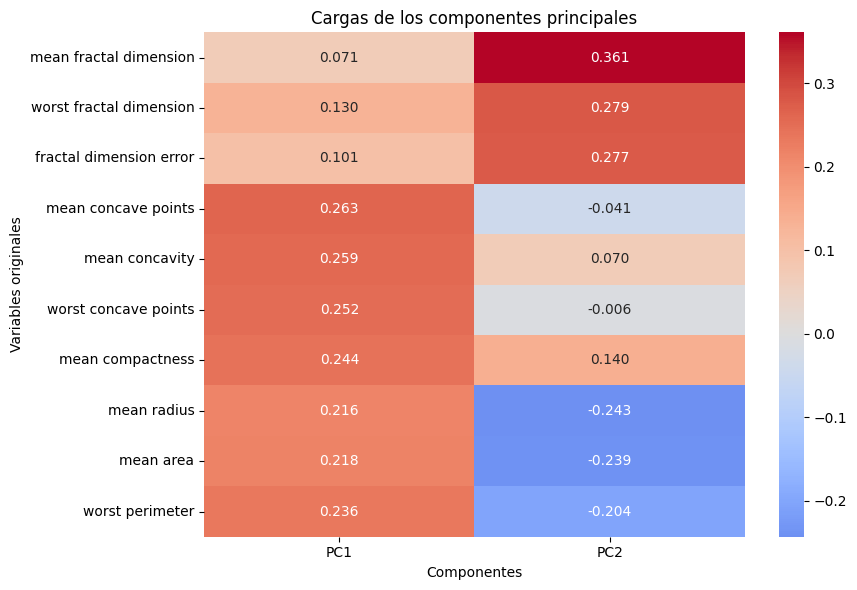

```python
# Obtener las cargas de los primeros dos componentes
cargas = pd.DataFrame(
    pca_completo.components_[:2].T,
    index=X.columns,
    columns=["PC1", "PC2"]
)

# Identificar las variables más importantes
for componente in ["PC1", "PC2"]:
    importantes = cargas[componente].abs().nlargest(5).index

    print(f"\nVariables más importantes para {componente}:")
    display(cargas.loc[importantes, [componente]].round(4))

# Visualización de las cargas
top_variables = cargas.abs().max(axis=1).nlargest(10).index

plt.figure(figsize=(9, 6))

sns.heatmap(
    cargas.loc[top_variables],
    annot=True,
    cmap="coolwarm",
    center=0,
    fmt=".3f"
)

plt.title("Cargas de los componentes principales")
plt.xlabel("Componentes")
plt.ylabel("Variables originales")
plt.tight_layout()
plt.show()
```

### Interpretación de las cargas

En el primer componente principal, las variables con mayor influencia son mean concave points, mean concavity y worst concave points. Estas características están relacionadas con la forma del tumor.

En el segundo componente destacan mean fractal dimension, worst fractal dimension y fractal dimension error. Esto indica que ambos componentes representan diferentes características de los tumores.

Los resultados muestran que PCA permite resumir la información original y conservar características importantes para la clasificación.

# Parte 2. Datos faltantes y reconstrucción de información

## 7. Exploración del conjunto de datos Wine

En esta parte se utilizará el conjunto de datos Wine para comparar diferentes métodos de imputación de valores faltantes.

Primero se revisarán las características de los datos y se entrenará un modelo de clasificación. Después se eliminará aleatoriamente el 30% de los valores de entrada para evaluar diferentes métodos de reconstrucción.

```python
from sklearn.datasets import load_wine

# Cargar el conjunto de datos Wine
wine = load_wine(as_frame=True)

X_wine = wine.data
y_wine = wine.target

print("Registros:", X_wine.shape[0])
print("Variables:", X_wine.shape[1])
print("Clases:", wine.target_names)
print("Valores faltantes:", X_wine.isna().sum().sum())

print("\nRegistros por clase:")
print(y_wine.value_counts().sort_index())

display(X_wine.head())
```

```
Registros: 178
Variables: 13
Clases: ['class_0' 'class_1' 'class_2']
Valores faltantes: 0

Registros por clase:
target
0    59
1    71
2    48
Name: count, dtype: int64
```

|  | alcohol | malic_acid | ash | alcalinity_of_ash | magnesium | total_phenols | flavanoids | nonflavanoid_phenols | proanthocyanins | color_intensity | hue | od280/od315_of_diluted_wines | proline |
| --- | --- | --- | --- | --- | --- | --- | --- | --- | --- | --- | --- | --- | --- |
| 0 | 14.23 | 1.71 | 2.43 | 15.6 | 127.0 | 2.80 | 3.06 | 0.28 | 2.29 | 5.64 | 1.04 | 3.92 | 1065.0 |
| 1 | 13.20 | 1.78 | 2.14 | 11.2 | 100.0 | 2.65 | 2.76 | 0.26 | 1.28 | 4.38 | 1.05 | 3.40 | 1050.0 |
| 2 | 13.16 | 2.36 | 2.67 | 18.6 | 101.0 | 2.80 | 3.24 | 0.30 | 2.81 | 5.68 | 1.03 | 3.17 | 1185.0 |
| 3 | 14.37 | 1.95 | 2.50 | 16.8 | 113.0 | 3.85 | 3.49 | 0.24 | 2.18 | 7.80 | 0.86 | 3.45 | 1480.0 |
| 4 | 13.24 | 2.59 | 2.87 | 21.0 | 118.0 | 2.80 | 2.69 | 0.39 | 1.82 | 4.32 | 1.04 | 2.93 | 735.0 |

## 8. Clasificación inicial con Wine

Se dividirán los datos en 70% entrenamiento y 30% prueba. Después se aplicará una regresión logística con estandarización para obtener los resultados iniciales de Accuracy, F1-score y AUC.

Estos resultados servirán como referencia para evaluar los métodos de imputación.

```python
from sklearn.model_selection import train_test_split, GridSearchCV
from sklearn.pipeline import make_pipeline
from sklearn.preprocessing import StandardScaler
from sklearn.linear_model import LogisticRegression
from sklearn.metrics import accuracy_score, f1_score, roc_auc_score

# Separar los datos
X_train_w, X_test_w, y_train_w, y_test_w = train_test_split(
    X_wine, y_wine,
    test_size=0.30,
    random_state=42,
    stratify=y_wine
)

# Modelo de clasificación
modelo_wine = make_pipeline(
    StandardScaler(),
    LogisticRegression(max_iter=5000, random_state=42)
)

parametros_wine = {
    "logisticregression__C": [0.01, 0.1, 1, 10, 100]
}

busqueda_wine = GridSearchCV(
    modelo_wine,
    parametros_wine,
    cv=5,
    scoring="f1_macro",
    n_jobs=-1
)

busqueda_wine.fit(X_train_w, y_train_w)

mejor_wine = busqueda_wine.best_estimator_

pred_wine = mejor_wine.predict(X_test_w)
prob_wine = mejor_wine.predict_proba(X_test_w)

print("Entrenamiento:", len(X_train_w))
print("Prueba:", len(X_test_w))
print("Mejor C:", busqueda_wine.best_params_)
print("Accuracy:", round(accuracy_score(y_test_w, pred_wine), 4))
print("F1-score macro:", round(f1_score(y_test_w, pred_wine, average="macro"), 4))
print("AUC multiclase:", round(roc_auc_score(
    y_test_w, prob_wine, multi_class="ovr", average="macro"
), 4))
```

```
Entrenamiento: 124
Prueba: 54
Mejor C: {'logisticregression__C': 1}
Accuracy: 0.9815
F1-score macro: 0.9829
AUC multiclase: 0.9995
```

### Interpretación de los resultados

El modelo obtuvo un Accuracy de 98.15%, un F1-score macro de 0.9829 y un AUC de 0.9995. Estos valores muestran que la regresión logística logra clasificar correctamente la mayoría de los vinos.

Los resultados servirán como referencia para comparar el desempeño cuando se introduzcan valores faltantes y se utilicen diferentes métodos de imputación.

## 9. Generación de valores faltantes

Se eliminará aleatoriamente aproximadamente el 30% de los valores de las variables de entrada, tanto en entrenamiento como en prueba. Las clases originales se conservarán.

Después se utilizará un mapa de calor para visualizar dónde se encuentran los valores faltantes. Esto permitirá evaluar posteriormente qué tan bien funcionan los diferentes métodos de imputación.

```
Valores faltantes en entrenamiento: 485
Valores faltantes en prueba: 214
Porcentaje faltante en entrenamiento: 30.09 %
Porcentaje faltante en prueba: 30.48 %
```

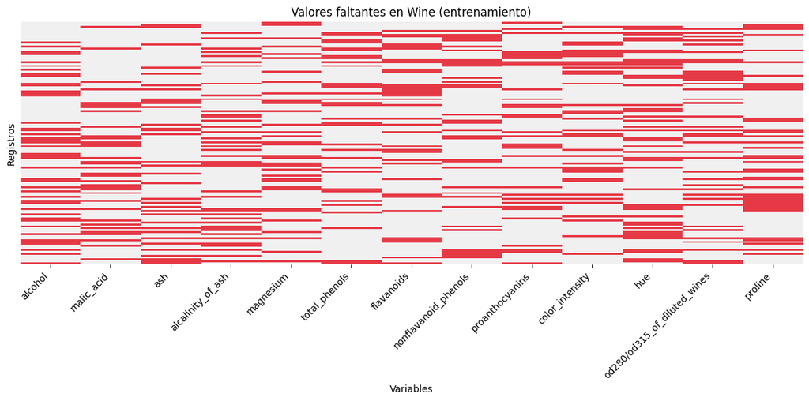

```python
# Generar valores faltantes aleatoriamente
rng = np.random.default_rng(42)

mask_train = rng.random(X_train_w.shape) < 0.30
mask_test = rng.random(X_test_w.shape) < 0.30

X_train_w_missing = X_train_w.mask(mask_train)
X_test_w_missing = X_test_w.mask(mask_test)

# Revisar valores faltantes
print("Valores faltantes en entrenamiento:",
      X_train_w_missing.isna().sum().sum())

print("Valores faltantes en prueba:",
      X_test_w_missing.isna().sum().sum())

print("Porcentaje faltante en entrenamiento:",
      round(X_train_w_missing.isna().mean().mean() * 100, 2), "%")

print("Porcentaje faltante en prueba:",
      round(X_test_w_missing.isna().mean().mean() * 100, 2), "%")

# Mapa de calor de valores faltantes
plt.figure(figsize=(12, 6))

sns.heatmap(
    X_train_w_missing.isna(),
    cmap=["#F0F0F0", "#E63946"],
    cbar=False,
    yticklabels=False
)

plt.title("Valores faltantes en Wine (entrenamiento)")
plt.xlabel("Variables")
plt.ylabel("Registros")
plt.xticks(rotation=45, ha="right")
plt.tight_layout()
plt.show()
```

### Interpretación de los valores faltantes

Se eliminaron aleatoriamente el 30.09% de los valores de entrenamiento y el 30.48% de los valores de prueba. En el mapa de calor se observa cómo se distribuyen los datos faltantes entre las diferentes variables.

Estos valores deberán recuperarse mediante métodos de imputación para poder entrenar y evaluar los modelos de clasificación.

## 10. Imputación de datos mediante media y KNN

Se utilizarán dos métodos para completar los valores faltantes. El primero reemplaza los datos ausentes con la media de cada variable, mientras que KNN utiliza observaciones similares para estimarlos.

Después se entrenarán modelos de regresión logística con ambos métodos y se compararán sus resultados mediante Accuracy, F1-score macro y AUC.

```
Comparación de métodos de imputación:
```

|  | Método | Accuracy | F1-score | AUC |
| --- | --- | --- | --- | --- |
| 0 | Original | 0.9815 | 0.9829 | 0.9995 |
| 1 | Media | 0.9074 | 0.9046 | 0.9813 |
| 2 | KNN | 0.8889 | 0.8909 | 0.9823 |

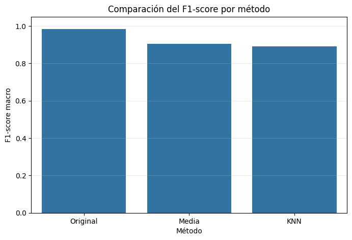

```python
from sklearn.impute import SimpleImputer, KNNImputer

# Métodos de imputación
metodos = {
    "Media": SimpleImputer(strategy="mean"),
    "KNN": KNNImputer(n_neighbors=5)
}

resultados_imputacion = []

# Modelo original sin valores faltantes
resultados_imputacion.append({
    "Método": "Original",
    "Accuracy": accuracy_score(y_test_w, pred_wine),
    "F1-score": f1_score(y_test_w, pred_wine, average="macro"),
    "AUC": roc_auc_score(
        y_test_w, prob_wine,
        multi_class="ovr", average="macro"
    )
})

# Evaluar media y KNN
for nombre, imputador in metodos.items():

    modelo = make_pipeline(
        imputador,
        StandardScaler(),
        LogisticRegression(
            C=1,
            max_iter=5000,
            random_state=42
        )
    )

    modelo.fit(X_train_w_missing, y_train_w)

    pred = modelo.predict(X_test_w_missing)
    prob = modelo.predict_proba(X_test_w_missing)

    resultados_imputacion.append({
        "Método": nombre,
        "Accuracy": accuracy_score(y_test_w, pred),
        "F1-score": f1_score(
            y_test_w, pred, average="macro"
        ),
        "AUC": roc_auc_score(
            y_test_w, prob,
            multi_class="ovr", average="macro"
        )
    })

tabla_imputacion = pd.DataFrame(resultados_imputacion)

print("Comparación de métodos de imputación:")
display(tabla_imputacion.round(4))

# Comparar F1-score
plt.figure(figsize=(8, 5))

sns.barplot(
    data=tabla_imputacion,
    x="Método",
    y="F1-score"
)

plt.title("Comparación del F1-score por método")
plt.ylabel("F1-score macro")
plt.ylim(0, 1.05)
plt.grid(axis="y", alpha=0.3)

plt.show()
```

### Interpretación de los métodos de imputación

Los resultados muestran que el modelo original obtuvo el mejor desempeño, con un F1-score de 0.9829.

Al introducir valores faltantes, el desempeño disminuyó. La imputación por media obtuvo un F1-score de 0.9046, mientras que KNN alcanzó 0.8909. Esto indica que, en esta prueba, reemplazar los valores faltantes mediante la media permitió conservar mejores resultados de clasificación que KNN.

## 11. Reconstrucción de datos mediante SoftImpute

Se utilizará SoftImpute para estimar los valores faltantes mediante una aproximación de bajo rango de la matriz de datos.

Primero se estandarizarán las variables y después se aplicará el método de reconstrucción. Finalmente, se entrenará una regresión logística para comparar los resultados con la imputación por media y KNN.

```python
!pip -q install fancyimpute
```

```python
from fancyimpute import SoftImpute

# Estandarizar usando entrenamiento
scaler_soft = StandardScaler()
scaler_soft.fit(X_train_w_missing)

train_scaled = scaler_soft.transform(X_train_w_missing)
test_scaled = scaler_soft.transform(X_test_w_missing)

# Unir las matrices para reconstrucción
n_train = len(X_train_w_missing)
matriz_incompleta = np.vstack([
    train_scaled,
    test_scaled
])

# Aplicar SoftImpute
soft = SoftImpute(
    max_iters=100,
    verbose=False
)

matriz_completa = soft.fit_transform(matriz_incompleta)

# Separar y regresar a la escala original
X_train_soft = scaler_soft.inverse_transform(
    matriz_completa[:n_train]
)

X_test_soft = scaler_soft.inverse_transform(
    matriz_completa[n_train:]
)

# Entrenar el modelo
modelo_soft = make_pipeline(
    StandardScaler(),
    LogisticRegression(
        C=1,
        max_iter=5000,
        random_state=42
    )
)

modelo_soft.fit(X_train_soft, y_train_w)

pred_soft = modelo_soft.predict(X_test_soft)
prob_soft = modelo_soft.predict_proba(X_test_soft)

# Evaluar resultados
resultado_soft = pd.DataFrame([{
    "Método": "SoftImpute",
    "Accuracy": accuracy_score(y_test_w, pred_soft),
    "F1-score": f1_score(
        y_test_w, pred_soft, average="macro"
    ),
    "AUC": roc_auc_score(
        y_test_w,
        prob_soft,
        multi_class="ovr",
        average="macro"
    )
}])

# Comparar todos los métodos
tabla_final_imputacion = pd.concat(
    [tabla_imputacion, resultado_soft],
    ignore_index=True
)

print("Comparación final de métodos:")
display(tabla_final_imputacion.round(4))

print("Valores faltantes después de SoftImpute:",
      np.isnan(matriz_completa).sum())
```

```
Comparación final de métodos:
```

|  | Método | Accuracy | F1-score | AUC |
| --- | --- | --- | --- | --- |
| 0 | Original | 0.9815 | 0.9829 | 0.9995 |
| 1 | Media | 0.9074 | 0.9046 | 0.9813 |
| 2 | KNN | 0.8889 | 0.8909 | 0.9823 |
| 3 | SoftImpute | 0.9259 | 0.9248 | 0.9930 |

```
Valores faltantes después de SoftImpute: 0
```

### Interpretación de SoftImpute

SoftImpute obtuvo un Accuracy de 92.59%, un F1-score de 0.9248 y un AUC de 0.9930, superando los resultados de Media y KNN.

Esto muestra que la reconstrucción mediante una aproximación de bajo rango permitió recuperar información útil para la clasificación. Aunque no alcanzó el desempeño del modelo original, fue el mejor de los tres métodos evaluados en esta prueba.

Para SoftImpute se utilizaron conjuntamente los datos de entrada de entrenamiento y prueba, sin utilizar sus etiquetas. Por eso, la comparación con los otros métodos es orientativa.

## 12. Evaluación del error de reconstrucción

Se compararán los valores reconstruidos con los originales para medir la calidad de cada método de imputación.

Se calcularán el error absoluto medio (MAE) y la raíz del error cuadrático medio (RMSE), utilizando los valores que fueron eliminados artificialmente del conjunto de prueba. Los errores se normalizarán por la desviación estándar de cada variable para poder compararlos en una misma escala.

Los valores más bajos indican una reconstrucción más cercana a los datos originales.

```python
# Reconstruir los valores faltantes con los tres métodos
media_imp = SimpleImputer(strategy="mean")
knn_imp = KNNImputer(n_neighbors=5)

media_imp.fit(X_train_w_missing)
knn_imp.fit(X_train_w_missing)

reconstrucciones = {
    "Media": media_imp.transform(X_test_w_missing),
    "KNN": knn_imp.transform(X_test_w_missing),
    "SoftImpute": X_test_soft
}

# Valores originales y posiciones eliminadas
original = X_test_w.to_numpy()
mascara = X_test_w_missing.isna().to_numpy()

# Normalizar errores para comparar variables
escalas = X_train_w.std(axis=0, ddof=0).to_numpy()
escalas[escalas == 0] = 1

errores = []

for nombre, reconstruido in reconstrucciones.items():
    diferencias = (original - reconstruido) / escalas
    valores_error = diferencias[mascara]

    mae = np.mean(np.abs(valores_error))
    rmse = np.sqrt(np.mean(valores_error**2))

    errores.append({
        "Método": nombre,
        "MAE normalizado": mae,
        "RMSE normalizado": rmse
    })

tabla_errores = pd.DataFrame(errores)

print("Errores de reconstrucción:")
display(tabla_errores.round(4))
```

```
Errores de reconstrucción:
```

|  | Método | MAE normalizado | RMSE normalizado |
| --- | --- | --- | --- |
| 0 | Media | 0.8461 | 1.0335 |
| 1 | KNN | 0.7018 | 0.8975 |
| 2 | SoftImpute | 0.6095 | 0.7884 |

### Interpretación del error de reconstrucción

SoftImpute obtuvo los errores más bajos, con un MAE normalizado de 0.6095 y un RMSE normalizado de 0.7884. Esto indica que fue el método que reconstruyó los valores faltantes con mayor precisión.

KNN obtuvo mejores resultados de reconstrucción que la media, aunque su F1-score de clasificación fue menor. Esto muestra que un menor error de reconstrucción no siempre significa una mejor clasificación.

En general, SoftImpute fue el método con mejores resultados en esta comparación.

# Parte 3. Sistema de recomendación de películas

## 13. Exploración del conjunto de datos MovieLens

En esta parte se utilizará MovieLens 100k, un conjunto de datos que contiene calificaciones de usuarios a diferentes películas.

El objetivo es construir un sistema de recomendación capaz de estimar las calificaciones que un usuario podría dar a películas que todavía no ha visto o calificado.

Primero se revisarán los datos y después se construirá una matriz usuario-película para aplicar un método de reconstrucción.

```python
import io
import zipfile
import urllib.request

# Descargar MovieLens 100k
url = "https://files.grouplens.org/datasets/movielens/ml-100k.zip"

with urllib.request.urlopen(url, timeout=60) as respuesta:
    archivo_zip = io.BytesIO(respuesta.read())

with zipfile.ZipFile(archivo_zip) as z:

    # Calificaciones de usuarios
    with z.open("ml-100k/u.data") as archivo:
        ratings = pd.read_csv(
            archivo,
            sep="\t",
            names=["user_id", "movie_id", "rating", "timestamp"]
        )

    # Información de películas
    with z.open("ml-100k/u.item") as archivo:
        movies_raw = pd.read_csv(
            archivo,
            sep="|",
            header=None,
            encoding="latin-1"
        )

# Géneros de películas
generos = [
    "Unknown", "Action", "Adventure", "Animation",
    "Children", "Comedy", "Crime", "Documentary",
    "Drama", "Fantasy", "Film-Noir", "Horror",
    "Musical", "Mystery", "Romance", "Sci-Fi",
    "Thriller", "War", "Western"
]

movies = movies_raw[[0, 1] + list(range(5, 24))].copy()
movies.columns = ["movie_id", "title"] + generos

movies["genres"] = movies[generos].apply(
    lambda fila: ", ".join(
        genero for genero in generos if fila[genero] == 1
    ),
    axis=1
)

movies = movies[["movie_id", "title", "genres"]]

# Revisar información
print("Total de calificaciones:", len(ratings))
print("Usuarios:", ratings["user_id"].nunique())
print("Películas:", movies["movie_id"].nunique())
print("Calificación mínima:", ratings["rating"].min())
print("Calificación máxima:", ratings["rating"].max())
print("Valores faltantes:", ratings.isna().sum().sum())

print("\nPrimeras calificaciones:")
display(ratings.head())

print("\nPrimeras películas:")
display(movies.head())
```

```
Total de calificaciones: 100000
Usuarios: 943
Películas: 1682
Calificación mínima: 1
Calificación máxima: 5
Valores faltantes: 0

Primeras calificaciones:
```

|  | user_id | movie_id | rating | timestamp |
| --- | --- | --- | --- | --- |
| 0 | 196 | 242 | 3 | 881250949 |
| 1 | 186 | 302 | 3 | 891717742 |
| 2 | 22 | 377 | 1 | 878887116 |
| 3 | 244 | 51 | 2 | 880606923 |
| 4 | 166 | 346 | 1 | 886397596 |

```
Primeras películas:
```

|  | movie_id | title | genres |
| --- | --- | --- | --- |
| 0 | 1 | Toy Story (1995) | Animation, Children, Comedy |
| 1 | 2 | GoldenEye (1995) | Action, Adventure, Thriller |
| 2 | 3 | Four Rooms (1995) | Thriller |
| 3 | 4 | Get Shorty (1995) | Action, Comedy, Drama |
| 4 | 5 | Copycat (1995) | Crime, Drama, Thriller |

## 14. Matriz usuario-película y preparación de datos

Se construirá una matriz donde las filas representan usuarios y las columnas representan películas. Cada valor corresponde a la calificación que un usuario le dio a una película.

Los espacios sin calificación se representarán mediante NaN. Después se ocultará aleatoriamente el 10% de las calificaciones disponibles para evaluar la capacidad del sistema de reconstruirlas.

Finalmente, se centrarán las calificaciones alrededor del promedio de cada usuario para considerar las diferencias entre usuarios que califican de manera más estricta o más flexible.

```python
# Crear matriz usuario-película
matriz = ratings.pivot(
    index="user_id",
    columns="movie_id",
    values="rating"
).sort_index().sort_index(axis=1)

print("Tamaño de la matriz:", matriz.shape)
print("Calificaciones disponibles:", matriz.notna().sum().sum())
print("Espacios sin calificación:", matriz.isna().sum().sum())

# Ocultar 10% de las calificaciones conocidas
rng = np.random.default_rng(42)

valores = matriz.to_numpy(copy=True)
indices = np.flatnonzero(~np.isnan(valores))

indices_ocultos = rng.choice(
    indices,
    size=int(len(indices) * 0.10),
    replace=False
)

filas_test, columnas_test = np.unravel_index(
    indices_ocultos, valores.shape
)

# Guardar calificaciones reales para evaluación
ratings_test_reales = valores[filas_test, columnas_test].copy()

# Ocultar calificaciones seleccionadas
valores[filas_test, columnas_test] = np.nan

matriz_entrenamiento = pd.DataFrame(
    valores,
    index=matriz.index,
    columns=matriz.columns
)

# Centrar las calificaciones por usuario
promedios_usuario = matriz_entrenamiento.mean(axis=1)

matriz_centrada = matriz_entrenamiento.sub(
    promedios_usuario,
    axis=0
)

print("\nCalificaciones ocultadas:", len(ratings_test_reales))
print("Calificaciones para entrenamiento:",
      matriz_entrenamiento.notna().sum().sum())

print("Usuarios sin calificaciones disponibles:",
      promedios_usuario.isna().sum())
```

```
Tamaño de la matriz: (943, 1682)
Calificaciones disponibles: 100000
Espacios sin calificación: 1486126

Calificaciones ocultadas: 10000
Calificaciones para entrenamiento: 90000
Usuarios sin calificaciones disponibles: 0
```

## 15. Visualización de calificaciones faltantes

Se utilizará un mapa de calor para identificar las calificaciones disponibles y los espacios sin información en la matriz usuario-película.

Para facilitar la visualización se mostrará una parte de la matriz, utilizando 100 usuarios y las 60 películas con más calificaciones. Los espacios marcados en rojo representan calificaciones faltantes que el sistema deberá estimar.

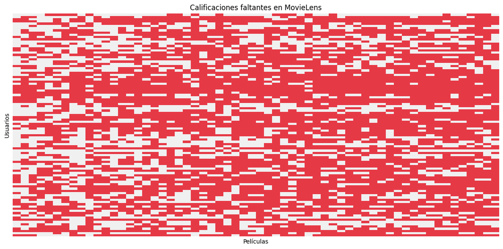

```python
# Seleccionar las 60 películas más calificadas
peliculas_vis = matriz_entrenamiento.notna().sum().nlargest(60).index

# Seleccionar los primeros 100 usuarios
matriz_vis = matriz_entrenamiento.loc[
    matriz_entrenamiento.index[:100],
    peliculas_vis
]

# Mostrar valores faltantes
plt.figure(figsize=(12, 6))

sns.heatmap(
    matriz_vis.isna(),
    cmap=["#F0F0F0", "#E63946"],
    cbar=False,
    yticklabels=False,
    xticklabels=False
)

plt.title("Calificaciones faltantes en MovieLens")
plt.xlabel("Películas")
plt.ylabel("Usuarios")
plt.tight_layout()
plt.show()
```

### Interpretación de la matriz usuario-película

La matriz contiene 943 usuarios y 1682 películas. Se ocultaron 10,000 calificaciones, que representan el 10% de las calificaciones originales, dejando 90,000 disponibles para el entrenamiento.

En el mapa de calor se observa que existen muchos espacios sin calificación. Esto ocurre porque los usuarios solamente han calificado una parte de las películas disponibles. El objetivo del sistema será estimar las calificaciones faltantes para poder generar recomendaciones.

## 16. Reconstrucción de calificaciones con SoftImpute

Se aplicará SoftImpute para estimar las calificaciones faltantes utilizando una aproximación de bajo rango de la matriz usuario-película.

Después se recuperará la escala original de las calificaciones y se calcularán los errores MAE y RMSE sobre las 10,000 calificaciones ocultadas. Esto permitirá medir qué tan cerca están las predicciones de las calificaciones reales.

```python
from fancyimpute import SoftImpute
from sklearn.metrics import mean_absolute_error, mean_squared_error

# Aplicar reconstrucción sobre la matriz centrada
modelo_recomendacion = SoftImpute(
    max_rank=15,
    max_iters=20,
    verbose=False
)

matriz_reconstruida = modelo_recomendacion.fit_transform(
    matriz_centrada.to_numpy(dtype=float)
)

# Recuperar promedios de cada usuario
calificaciones_estimadas = (
    matriz_reconstruida +
    promedios_usuario.to_numpy()[:, None]
)

# Mantener las calificaciones entre 1 y 5
calificaciones_estimadas = np.clip(
    calificaciones_estimadas, 1, 5
)

# Evaluar las 10,000 calificaciones ocultadas
predicciones_test = calificaciones_estimadas[
    filas_test, columnas_test
]

mae_recomendacion = mean_absolute_error(
    ratings_test_reales, predicciones_test
)

rmse_recomendacion = np.sqrt(
    mean_squared_error(
        ratings_test_reales, predicciones_test
    )
)

print("Resultados de reconstrucción MovieLens")
print("Calificaciones evaluadas:", len(ratings_test_reales))
print("MAE:", round(mae_recomendacion, 4))
print("RMSE:", round(rmse_recomendacion, 4))
print("Valores faltantes después de reconstrucción:",
      np.isnan(calificaciones_estimadas).sum())
```

```
Resultados de reconstrucción MovieLens
Calificaciones evaluadas: 10000
MAE: 0.7597
RMSE: 0.9774
Valores faltantes después de reconstrucción: 0
```

### Interpretación de la reconstrucción

El sistema obtuvo un MAE de 0.7597 y un RMSE de 0.9774 al evaluar las 10,000 calificaciones ocultadas.

Esto significa que las predicciones presentan un error promedio de aproximadamente 0.76 puntos en una escala de 1 a 5. Aunque las estimaciones no son exactas, permiten identificar películas que podrían interesarle a cada usuario.

## 17. Generación de recomendaciones

Se seleccionará un usuario aleatorio y se identificarán las películas que todavía no ha calificado.

El sistema utilizará las calificaciones estimadas para recomendar las 10 películas con mayor puntuación. También se mostrarán sus títulos y géneros para facilitar la interpretación de los resultados.

```python
# Seleccionar un usuario aleatorio
rng_usuario = np.random.default_rng(42)
usuario_id = int(rng_usuario.choice(matriz.index))

# Obtener sus calificaciones estimadas
pos_usuario = matriz.index.get_loc(usuario_id)

estimaciones_usuario = pd.Series(
    calificaciones_estimadas[pos_usuario],
    index=matriz.columns,
    name="calificacion_estimada"
)

# Excluir películas que el usuario ya calificó
peliculas_no_calificadas = matriz.loc[usuario_id].isna()

# Seleccionar las 10 mejores recomendaciones
recomendaciones = (
    estimaciones_usuario[peliculas_no_calificadas]
    .sort_values(ascending=False)
    .head(10)
    .rename_axis("movie_id")
    .reset_index()
)

# Agregar título y género
recomendaciones = recomendaciones.merge(
    movies,
    on="movie_id",
    how="left"
)

recomendaciones = recomendaciones[
    ["title", "genres", "calificacion_estimada"]
]

recomendaciones["calificacion_estimada"] = (
    recomendaciones["calificacion_estimada"].round(2)
)

print("Usuario seleccionado:", usuario_id)
print("Películas calificadas:",
      matriz.loc[usuario_id].notna().sum())

print("\nTop 10 películas recomendadas:")
display(recomendaciones)
```

```
Usuario seleccionado: 85
Películas calificadas: 288

Top 10 películas recomendadas:
```

|  | title | genres | calificacion_estimada |
| --- | --- | --- | --- |
| 0 | 12 Angry Men (1957) | Drama | 4.48 |
| 1 | Close Shave, A (1995) | Animation, Comedy, Thriller | 4.38 |
| 2 | Secrets & Lies (1996) | Drama | 4.36 |
| 3 | L.A. Confidential (1997) | Crime, Film-Noir, Mystery, Thriller | 4.32 |
| 4 | Rear Window (1954) | Mystery, Thriller | 4.24 |
| 5 | Shadowlands (1993) | Drama, Romance | 4.20 |
| 6 | Wrong Trousers, The (1993) | Animation, Comedy | 4.18 |
| 7 | Apostle, The (1997) | Drama | 4.17 |
| 8 | Waiting for Guffman (1996) | Comedy | 4.17 |
| 9 | Big Night (1996) | Drama | 4.17 |

### Interpretación de las recomendaciones

El sistema seleccionó al usuario 85, quien había calificado 288 películas. A partir de las calificaciones estimadas se generaron 10 recomendaciones de películas que el usuario no había calificado.

La película con mayor puntuación estimada fue 12 Angry Men (1957), con 4.48, seguida de Close Shave, A (1995), con 4.38.

Estos resultados muestran cómo la reconstrucción de la matriz permite estimar las preferencias de los usuarios y recomendar películas según sus posibles intereses.

## 18. Conclusión general

En esta actividad se aplicaron diferentes técnicas de análisis y procesamiento de datos.

En la primera parte, PCA permitió reducir la cantidad de variables y mantener buenos resultados de clasificación. El modelo con 5 componentes obtuvo el mejor F1-score de 0.9841.

En la segunda parte se compararon métodos para recuperar valores faltantes. SoftImpute obtuvo los mejores resultados generales entre los métodos evaluados, tanto en clasificación como en reconstrucción.

Finalmente, se desarrolló un sistema de recomendación utilizando MovieLens 100k. El modelo permitió estimar calificaciones faltantes y recomendar películas a un usuario según sus posibles preferencias.

En general, los resultados muestran la utilidad de PCA y la reconstrucción de matrices para analizar información y generar predicciones.